# Electromagnetism Homework #5

# Problems marked with [*] are potential sources for quiz questions.

## [*] Problem 1: P-Polarization (Parallel Polarization)

The reflection and transmission coefficients for waves polarized *parallel* to the plane of incidence are:

$$R_p \equiv \frac{I_R}{I_I} = \left(\frac{E_{0,R}}{E_{0,I}}\right)^2 = \left(\frac{\alpha - \beta}{\alpha + \beta}\right)^2$$

$$T_p \equiv \frac{I_T}{I_I} = \frac{\epsilon_2 v_2}{\epsilon_1 v_1}\left(\frac{E_{0,T}}{E_{0,I}}\right)\frac{\cos\theta_T}{\cos\theta_I} = \alpha\beta\left(\frac{2}{\alpha + \beta}\right)^2$$

with,

$$\beta = \frac{\mu_1 n_2}{\mu_2 n_1} \qquad \text{and} \qquad \alpha = \frac{\cos\theta_T}{\cos\theta_I} = \frac{\sqrt{1 - \left(\frac{n_1}{n_2}\sin\theta_I\right)^2}}{\cos\theta_I}$$

Plot $R_p$ and $T_p$ vs $\theta_I$ for $0 \leq \theta_i < 90°$ for an air-diamond interface. $n_{\text{air}} = 1$, $n_{\text{diamond}} = 2.42$. Assume $\mu_{\text{air}} = \mu_{\text{diamond}} = \mu_0$. Calculate and mark Brewster's angle where $R_p = 0$, $\theta_B$, for these materials and indicate it on the plot.

## Problem 1 Solution:

Brewster's angle describes the angle of incidence where light with a certain polarization is perfectly transmitted through a transparent $\textbf{dielectric}$ surface with no reflection. In this case $R_{p} = 0$.

Assuming $\mu_{1} = \mu_{2} = \mu_{0}$, the calculations of Brewser's angle can be done:

$$\theta_{B} = arctan(\frac{n_{2}}{n_{1}})$$

Given $n_{ait} = 1$ and $n_{diamond} = 2.42$:

$$\theta_{B} = arctan(\frac{2.42}{1})$$

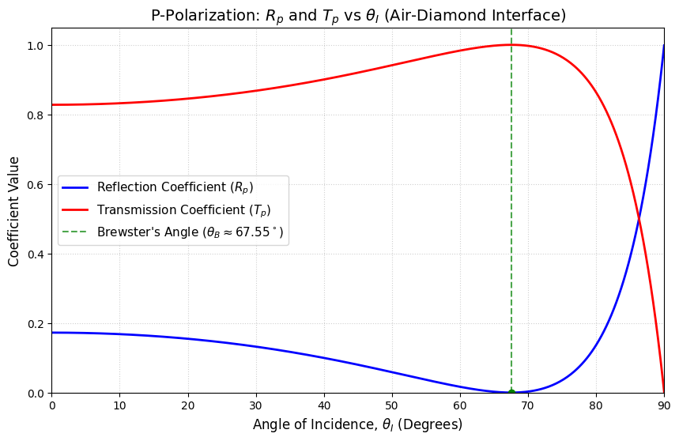

```python
import numpy as np
import matplotlib.pyplot as plt

# Given constants
n1 = 1.0       # n_air
n2 = 2.42      # n_diamond
mu_ratio = 1.0 # mu1/mu2 = 1 since both are mu_0

# Array of incident angles from 0 to just under 90 degrees (in radians)
theta_I_deg = np.linspace(0, 89.99, 500)
theta_I = np.radians(theta_I_deg)

# Calculate Beta
beta = mu_ratio * (n2 / n1)

# Calculate Alpha
# Using the given formula: alpha = sqrt(1 - (n1/n2 * sin(theta_I))^2) / cos(theta_I)
numerator = np.sqrt(1 - (n1 / n2 * np.sin(theta_I))**2)
denominator = np.cos(theta_I)
alpha = numerator / denominator

# Calculate Reflection (Rp) and Transmission (Tp) coefficients
Rp = ((alpha - beta) / (alpha + beta))**2
Tp = alpha * beta * (2 / (alpha + beta))**2

# Calculate Brewster's Angle
theta_B_rad = np.arctan(n2 / n1)
theta_B_deg = np.degrees(theta_B_rad)

# Plotting
plt.figure(figsize=(10, 6))
plt.plot(theta_I_deg, Rp, label=r'Reflection Coefficient ($R_p$)', color='blue', linewidth=2)
plt.plot(theta_I_deg, Tp, label=r'Transmission Coefficient ($T_p$)', color='red', linewidth=2)

# Mark Brewster's Angle
plt.axvline(x=theta_B_deg, color='green', linestyle='--', alpha=0.7, label=rf"Brewster's Angle ($\theta_B \approx {theta_B_deg:.2f}^\circ$)")
plt.plot(theta_B_deg, 0, 'go') # Point where Rp = 0

# Formatting the plot
plt.title(r'P-Polarization: $R_p$ and $T_p$ vs $\theta_I$ (Air-Diamond Interface)', fontsize=14)
plt.xlabel(r'Angle of Incidence, $\theta_I$ (Degrees)', fontsize=12)
plt.ylabel('Coefficient Value', fontsize=12)
plt.xlim(0, 90)
plt.ylim(0, 1.05)
plt.grid(True, linestyle=':', alpha=0.6)
plt.legend(fontsize=11)

plt.show()
```

## [*] Problem 2: S-Polarization (Perpendicular Polarization)

Analyze the case of polarization *perpendicular* to the plane of incidence (that is, electric fields in the $y$ direction) as illustrated in the figure below. Do the following:

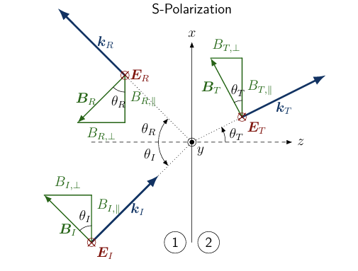

**(a)** Impose the boundary conditions for linear media:

$$\epsilon_1 E_1^{\perp} = \epsilon_2 E_2^{\perp} \qquad \mathbf{E}_1^{\parallel} = \mathbf{E}_2^{\parallel}$$

$$B_1^{\perp} = B_2^{\perp} \qquad \frac{1}{\mu_1}\mathbf{B}_1^{\parallel} = \frac{1}{\mu_2}\mathbf{B}_2^{\parallel}$$

and obtain the general Fresnel equations for $E_{0,R}$ and $E_{0,T}$. You should find:

$$\frac{E_{0,R}}{E_{0,I}} = \frac{1 - \alpha\beta}{1 + \alpha\beta}, \qquad \frac{E_{0,T}}{E_{0,I}} = \frac{2}{1 + \alpha\beta}$$

with,

$$\alpha = \frac{\cos\theta_T}{\cos\theta_I} = \frac{\sqrt{1 - \left(\frac{n_1}{n_2}\sin\theta_I\right)^2}}{\cos\theta_I}, \qquad \beta = \frac{\mu_1 n_2}{\mu_2 n_1}$$

**(b)** Plot $E_{0,R}/E_{0,I}$ and $E_{0,T}/E_{0,I}$ vs $\theta_i$ for the case $\beta = n_2/n_1 = 1.5$ and $\mu_1 = \mu_2 = \mu_0$. (Note for this $\beta$ the reflected wave is *always* 180° out of phase.)

**(c)** Show that for nonmagnetic media ($\mu_1 = \mu_2 = \mu_0$) there is no Brewster angle for S-polarization: $E_{0,R}$ is *never* zero (unless, of course, $n_1 = n_2$, in which case the two media are optically indistinguishable).

**(e)** Compute the reflection and transmission coefficients, and check that they add up to 1. You should find:

$$R_s = \left(\frac{1 - \alpha\beta}{1 + \alpha\beta}\right)^2, \qquad T_s = \alpha\beta\left(\frac{2}{1 + \alpha\beta}\right)^2$$

with $\alpha$ and $\beta$ defined earlier.

**(f)** Plot $R_s$ and $T_s$ vs $\theta_I$ for an air-diamond interface. $n_{\text{air}} = 1$, $n_{\text{diamond}} = 2.42$. Assume $\mu_{\text{air}} = \mu_{\text{diamond}} = \mu_0$.

## Problem 2 Solution:

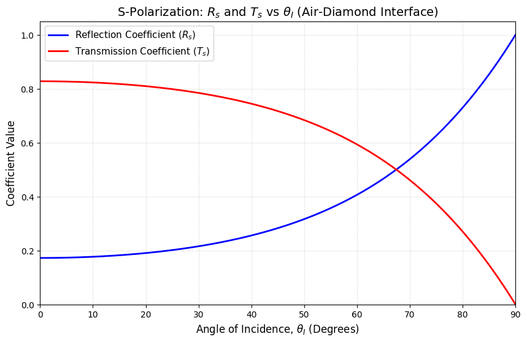

```python
# Constants
n1 = 1.0       # n_air
n2 = 2.42      # n_diamond
mu_ratio = 1.0 # mu1/mu2

# Incident angles
theta_I_deg = np.linspace(0, 89.99, 500)
theta_I = np.radians(theta_I_deg)

# Calculate Beta and Alpha
beta = mu_ratio * (n2 / n1)
numerator = np.sqrt(1 - (n1 / n2 * np.sin(theta_I))**2)
denominator = np.cos(theta_I)
alpha = numerator / denominator

# Calculate S-Polarization Coefficients
Rs = ((1 - alpha * beta) / (1 + alpha * beta))**2
Ts = alpha * beta * (2 / (1 + alpha * beta))**2

# Plotting
plt.figure(figsize=(10, 6))
plt.plot(theta_I_deg, Rs, label=r'Reflection Coefficient ($R_s$)', color='blue', linewidth=2)
plt.plot(theta_I_deg, Ts, label=r'Transmission Coefficient ($T_s$)', color='red', linewidth=2)

# Formatting
plt.title(r'S-Polarization: $R_s$ and $T_s$ vs $\theta_I$ (Air-Diamond Interface)', fontsize=14)
plt.xlabel(r'Angle of Incidence, $\theta_I$ (Degrees)', fontsize=12)
plt.ylabel('Coefficient Value', fontsize=12)
plt.xlim(0, 90)
plt.ylim(0, 1.05)
plt.grid(True, linestyle=':', alpha=0.6)
plt.legend(fontsize=11)
plt.show()
```

## Problem 3: Index of Refraction of Water

In the homework folder there is a file named `index-of-refraction-and-absorption-of-water.csv` which was copied from the table found here: https://en.wikipedia.org/wiki/Optical_properties_of_water_and_ice. Do the following:

**(a)** Make a plot of the index of refraction vs. wavelength in the range 200 to 1000-nm. Label the axes and give the plot an appropriate title.

**(b)** Fit the data to Cauchy's formula for the index of refraction,

$$n(\lambda) = A + \frac{B}{\lambda^2} + \frac{C}{\lambda^4},$$

and determine the best-fit values for $A$, $B$, and $C$. Include the fit on the plot with the data. Refer to the curve-fitting tutorial in the homework folder if needed.

**(c)** Determine a range of wavelengths that correspond to "red" and "blue" light and find a representative value of the index of refraction for each color.

## Problem 3 Solution:

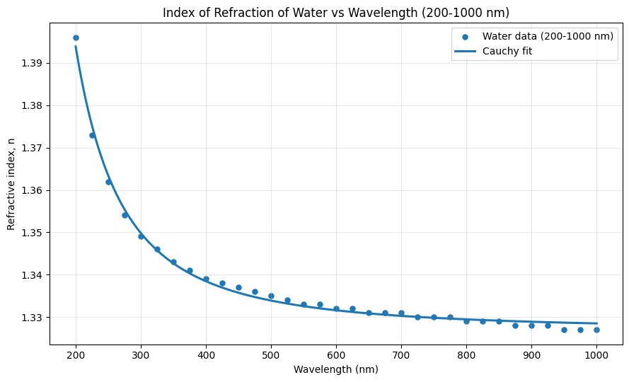

```
Solutions to part (b):
Cauchy fit coefficients:
A = 1.32686543
B = 0.00157624 (um^2)
C = 0.00004414 (um^4)

Solutions to part (c):
Representative wavelength ranges:
Red: 620-750 nm
Blue: 450-495 nm
Representative n_red (mean over range)  = 1.33083
Representative n_blue (mean over range) = 1.33650

Cauchy n(700 nm) = 1.33027
Cauchy n(450 nm) = 1.33573
```

```python
import pandas as pd
from scipy.optimize import curve_fit

# File path
csv_path = "index-of-refraction-and-absorption-of-water.csv"

# Read CSV (header has spaces/newline quirks, so clean names after reading)
df = pd.read_csv(csv_path)
df.columns = [c.strip() for c in df.columns]

# Find wavelength and n columns robustly
wl_col = [c for c in df.columns if "Wavelength" in c][0]
n_col = [c for c in df.columns if c.strip() == "n"][0]

# Keep only needed columns and force numeric
data = df[[wl_col, n_col]].copy()
data[wl_col] = pd.to_numeric(data[wl_col], errors="coerce")
data[n_col] = pd.to_numeric(data[n_col], errors="coerce")
data = data.dropna()

# Convert wavelength to nm for plotting/filtering
data["wavelength_um"] = data[wl_col]
data["wavelength_nm"] = 1000.0 * data["wavelength_um"]
data["n"] = data[n_col]

# Problem asks 200 to 1000 nm
fit_data = data[(data["wavelength_nm"] >= 200) & (data["wavelength_nm"] <= 1000)].copy()

lam_um = fit_data["wavelength_um"].to_numpy()
n_vals = fit_data["n"].to_numpy()

# Cauchy fit: n(lambda) = A + B/lambda^2 + C/lambda^4
# Use linear least squares on transformed basis (no scipy needed)
X = np.column_stack([
    np.ones_like(lam_um),
    1.0 / (lam_um**2),
    1.0 / (lam_um**4)
])
A, B, C = np.linalg.lstsq(X, n_vals, rcond=None)[0]

def cauchy(lam_um):
    return A + B/(lam_um**2) + C/(lam_um**4)

# Smooth curve for plotting
lam_plot_um = np.linspace(0.2, 1.0, 500)
lam_plot_nm = 1000.0 * lam_plot_um
n_plot = cauchy(lam_plot_um)

# Plot data + fit
plt.figure(figsize=(9, 5.5))
plt.scatter(fit_data["wavelength_nm"], fit_data["n"], s=26, label="Water data (200-1000 nm)")
plt.plot(lam_plot_nm, n_plot, linewidth=2.2, label="Cauchy fit")
plt.xlabel("Wavelength (nm)")
plt.ylabel("Refractive index, n")
plt.title("Index of Refraction of Water vs Wavelength (200-1000 nm)")
plt.grid(True, alpha=0.3)
plt.legend()
plt.tight_layout()
plt.show()

print(f"Solutions to part (b):")
print(f"Cauchy fit coefficients:")
print(f"A = {A:.8f}")
print(f"B = {B:.8f} (um^2)")
print(f"C = {C:.8f} (um^4)")

# Part (c): representative red/blue ranges and values
red_range = fit_data[(fit_data["wavelength_nm"] >= 620) & (fit_data["wavelength_nm"] <= 750)]
blue_range = fit_data[(fit_data["wavelength_nm"] >= 450) & (fit_data["wavelength_nm"] <= 495)]

n_red_rep = red_range["n"].mean()
n_blue_rep = blue_range["n"].mean()

print(f"\nSolutions to part (c):")
print("Representative wavelength ranges:")
print("Red: 620-750 nm")
print("Blue: 450-495 nm")
print(f"Representative n_red (mean over range)  = {n_red_rep:.5f}")
print(f"Representative n_blue (mean over range) = {n_blue_rep:.5f}")

# Optional: values at specific wavelengths often used in optics
n_700 = cauchy(0.700)
n_450 = cauchy(0.450)
print(f"\nCauchy n(700 nm) = {n_700:.5f}")
print(f"Cauchy n(450 nm) = {n_450:.5f}")
```

## Problem 4: Reflection Formula Derivation

Derive the Reflection Formula: A light ray with direction vector $\boldsymbol{v}_i$ strikes a smooth surface at a point where the unit normal vector is $\hat{n}$. The reflected ray direction is denoted $\boldsymbol{v}_r$. See illustration below.

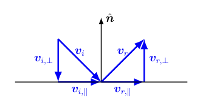

**(a)** Decompose $\boldsymbol{v}_i$ into components parallel and perpendicular to the surface.

**(b)** Show that the component perpendicular to the surface can be written: $\boldsymbol{v}_{i,\perp} = (\boldsymbol{v}_i \cdot \hat{n})\hat{n}$.

**(c)** Argue that $\boldsymbol{v}_{i,\parallel} = \boldsymbol{v}_i - \boldsymbol{v}_{i,\perp}$.

**(d)** To reflect the ray, the parallel component, $\boldsymbol{v}_{r,\parallel}$, remains unchanged, while the perpendicular component, $\boldsymbol{v}_{r,\perp}$, reverses direction. How would you write this as a vector equation?

**(e)** Using the previous step, show that the reflection formula can be written:

$$\boldsymbol{v}_r = \boldsymbol{v}_i - 2(\boldsymbol{v}_i \cdot \hat{n})\hat{n}$$

**(f)** Apply your result to compute the reflected direction of the vector $\boldsymbol{v}_i = 0.8\hat{x} - 0.6\hat{y}$ off a surface with normal $\hat{n} = 0\hat{x} + 1\hat{y}$. Does your result make sense?

## Problem 4 Solution:

#### Part (a):

This is pretty simple: $$v_{i} = v_{i,\perp} + v_{i, \parallel}$$

#### Part (b):

After some research and rememberence of how dot products and scalar projections work, I found that the perpendicular component is just the projection of $v_{i}$ onto $\hat{n}$. By definition of the dot product, the scalar projection is $v_{i}\times \hat{n}$, so the vector componoent is: $$v_{i,\perp} = (v_{i} \cdot \hat{n})\hat{n}$$

#### Part (c):

This is just a rearrangement of part (a). Its simple math.

#### Part (d):

$$v_{r} = v_{r, \parallel} + v_{r,\perp} = v_{r, \parallel} - v_{r,\perp}$$

#### Part (e):

To do this we just have to plug in part b and part c to part d: $$v_{r} = (v_{i} - v_{i,\perp})-v_{i,\perp} = v_{i} - 2v_{i,\perp} = v_{i} - 2(v_{i} \cdot \hat{n})\hat{n}$$

#### Part (f):

If we take the given functions/ values of $v_{i}$ and $\hat{n}$, then we can plug them into the equation we got in part (e). $$v_{i} \cdot \hat{n} = -0.6$$ and, $$v_{r} = [0.8, -0.6] - 2(-0.6)[0,1] = [0.8, 0.6]$$ THis makes sense because the x-component is unchanged, and the y-component flipped from -0.6 to +0.6.

## Problem 5: The Rainbow

Here we work through the multiple reflections and refractions that give rise to the rainbow. Consider a ray of sunlight incident from the left a distance $h$ above the $x$-axis on a spherical drop of water with radius 1 centered at the origin such that $0 < h < 1$, as illustrated in Figure 1. The index of refraction for air, $n_{\text{air}} = 1$, and use your index of refraction values for red and blue light from a previous problem.

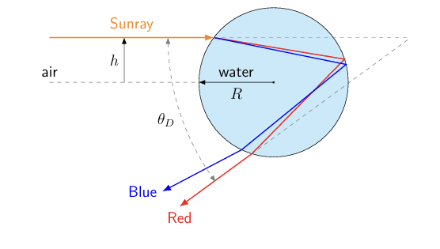

**Figure 1 NOTE:** the indices of refraction are $n_{\text{red}} = 1.3$ for red light (700nm) and $n_{\text{blue}} = 1.4$ for blue light (400nm) in this figure for illustration purposes only.

**(a) Point of Entry and Surface Normal:** The entry point on the circle is,

$$\boldsymbol{r}_1 = -(\sqrt{R^2 - h^2})\hat{x} + h\hat{y}$$

The outward unit normal at this point is:

$$\hat{n} = \frac{\boldsymbol{r}_1}{R} = -\frac{\sqrt{R^2 - h^2}}{R}\hat{x} + \frac{h}{R}\hat{y}$$

Pick a value of $h$ in the range $0 < h < 1$ and calculate the vectors $\boldsymbol{r}_1$ and $\hat{n}$ for $R = 1$.

**(b) Incident Angle & Transmitted Angle:** The incoming sunray is in the direction,

$$\boldsymbol{v}_{\text{in}} = +1\hat{x} + 0\hat{y}$$

Determine the angle of incidence, $\theta_i$, by computing the angle between the incoming ray direction (from the Sun) and the outward normal using the dot product formula:

$$\theta_i = \arccos(-\boldsymbol{v}_{\text{in}} \cdot \hat{n})$$

(Note: we use the negative dot product since the ray comes from outside the drop.) Calculate $\theta_i$ for your choice of $h$.

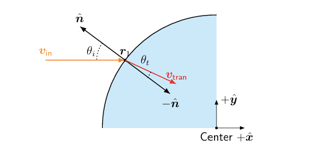

Use Snell's Law to calculate the transmission angle:

$$n_{\text{air}} \sin\theta_i = n_{\text{red}} \sin\theta_t \quad \Rightarrow \quad \theta_t = \arcsin\!\left(\frac{n_{\text{air}}}{n_{\text{red}}}\sin\theta_i\right)$$

Compute $\theta_t$ for red light for your value of $\theta_i$.

**(c) Direction of Refracted Ray:** Rotate the inward-pointing surface normal by the transmission angle to construct the new direction vector for the transmitted ray inside the drop. The inward normal is $-\hat{n}$. We rotate this vector **counter-clockwise** by $\theta_t$ to obtain the transmitted ray direction using matrix multiplication:

$$\boldsymbol{v}_{\text{trans}} = \mathcal{R}(\theta_t)(-\hat{n})$$

with the 2D rotation matrix:

$$\mathcal{R}(\theta) = \begin{bmatrix} \cos\theta & -\sin\theta \\ \sin\theta & \cos\theta \end{bmatrix}$$

and

$$-\hat{n} = \frac{\sqrt{R^2 - h^2}}{R}\hat{x} - \frac{h}{R}\hat{y} = \begin{bmatrix} \sqrt{R^2 - h^2}/R \\ -h/R \end{bmatrix}$$

Compute $\boldsymbol{v}_{\text{trans}}$ using your calculated value of $\theta_t$.

**(d) First Internal Reflection Location:** Recall $\boldsymbol{r}_1$ is the point where the ray enters the raindrop. Let $\hat{t}$ be the unit vector pointing in the direction of the ray after it has refracted inside the drop, in the direction of $\boldsymbol{v}_{\text{trans}}$:

$$\hat{t} = \frac{\boldsymbol{v}_{\text{trans}}}{\|\boldsymbol{v}_{\text{trans}}\|}$$

Compute $\hat{t}$ from $\boldsymbol{v}_{\text{trans}}$. We now wish to find the point $\boldsymbol{r}_2$ where this ray next intersects the boundary of the raindrop. Since the drop is a circle of radius $R = 1$ centered at the origin, the ray inside follows a parametric path of the form:

$$\boldsymbol{x}(s) = \boldsymbol{r}_1 + s\hat{t}, \quad s > 0$$

The intersection point is on the circle so $\|\boldsymbol{x}(s)\|^2 = R^2 (= 1)$. Substituting and expanding gives a quadratic equation in $s$:

$$s^2 + 2(\boldsymbol{r}_1 \cdot \hat{t})s + (\|\boldsymbol{r}_1\|^2 - R^2) = 0$$

Solving this gives two values of $s$:

$$s = \frac{-2(\boldsymbol{r}_1 \cdot \hat{t}) \pm \sqrt{[2(\boldsymbol{r}_1 \cdot \hat{t})]^2 - 4(\|\boldsymbol{r}_1\|^2 - R^2)}}{2}$$

with $R = 1$. The **smaller root**, $s_1$, corresponds to the original point $\boldsymbol{r}_1$. The **larger root**, $s_2$, gives the location of the second intersection:

$$\boldsymbol{r}_2 = \boldsymbol{r}_1 + s_2\hat{t}$$

Compute the roots $s_1$ and $s_2$. Use $s_2$ to determine $\boldsymbol{r}_2$.

**(e) Internal Reflection:** At this new point $\boldsymbol{r}_2$, the **interior** surface normal is:

$$\hat{n}_2 = -\frac{\boldsymbol{r}_2}{\|\boldsymbol{r}_2\|} = -\frac{\boldsymbol{r}_2}{R}, \quad \text{with } R = 1$$

Compute $\hat{n}_2$ at $\boldsymbol{r}_2$. We then apply the vector reflection formula (previous problem) to compute the new direction:

$$\hat{r} = \hat{t} - 2(\hat{t} \cdot \hat{n}_2)\hat{n}_2$$

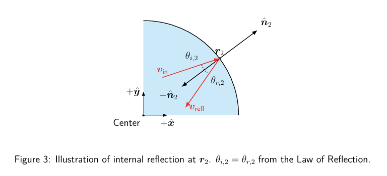

This reflected direction $\hat{r}$ is the direction in which the ray will travel, $\boldsymbol{v}_{\text{refl}}$, toward the opposite wall of the drop for potential refraction and exit.

**(f) Exit Refraction:** Let $\boldsymbol{r}_3$ be the third intersection point on the circle. Find this point via a similar method as in part (d). At this point, compute the new angle of incidence $\theta_{i,3}$ relative to the inward surface normal $-\hat{n}_3 = -\boldsymbol{r}_3/R$, with $R = 1$:

$$\theta_{i,3} = \arccos\!\left(-\boldsymbol{v}_{\text{refl}} \cdot (-\hat{n}_3)\right)$$

where $\boldsymbol{v}_{\text{refl}} = \boldsymbol{v}_{\text{in}}$ in Figure 4.

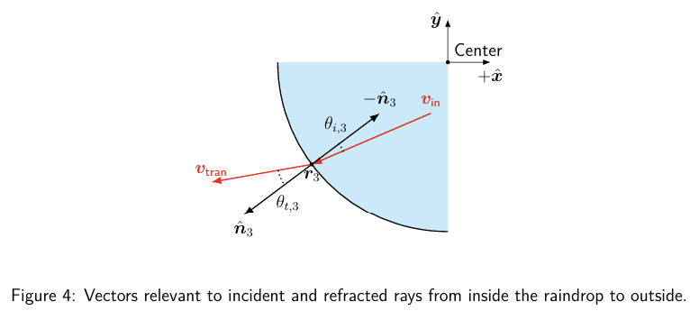

Then use Snell's Law to compute the transmission angle:

$$\theta_{t,3} = \arcsin\!\left(\frac{n_{\text{red}}}{n_{\text{air}}}\sin\theta_{i,3}\right)$$

The final exit direction is computed by rotating the normal vector $\hat{n}_3$ **clockwise** by $\theta_{t,3}$ via matrix multiplication:

$$\boldsymbol{v}_{\text{exit}} = \mathcal{R}(-\theta_{t,3})\hat{n}_3$$

Note: Clockwise rotations are negative angles. Counter-clockwise rotations are positive angles. Determine $\theta_{t,3}$ and $\boldsymbol{v}_{\text{exit}}$.

**(g) Scattering Angle (Rainbow Angle):** The observable scattering angle between the incident sunlight direction and the exiting ray is called the **deviation angle**, denoted $\Theta_D$. We define the deviation angle as the angle between the reversed incident direction ($-\boldsymbol{v}_{\text{incident}}$) and the final exit direction $\boldsymbol{v}_{\text{exit}}$:

$$\Theta_D = \cos^{-1}\!\left(\frac{(-\boldsymbol{v}_{\text{incident}}) \cdot \boldsymbol{v}_{\text{exit}}}{\|\boldsymbol{v}_{\text{incident}}\| \cdot \|\boldsymbol{v}_{\text{exit}}\|}\right)$$

Since both vectors are unit length in our construction, this simplifies to:

$$\Theta_D = \cos^{-1}(-\boldsymbol{v}_{\text{incident}} \cdot \boldsymbol{v}_{\text{exit}})$$

**(h)** Now that you have a sequence of steps to go from a choice of $h$ (subject to $0 < h < 1$) to $\boldsymbol{v}_{\text{exit}}$, automate the process and vary the entry height $h$ over the range $0 < h < 1$ and compute the deviation angle $\Theta_D$ as a function of $h$. Plot $\Theta(h)$, and determine the extremum of the deviation function for red light. Repeat for blue light. Which is deviated more?

This maximum in deviation angle defines the angle at which a concentration of rays exit the drop, leading to the bright arc of the primary rainbow. For red light in water, this angle is typically close to $42°$ as illustrated in Figure 5.

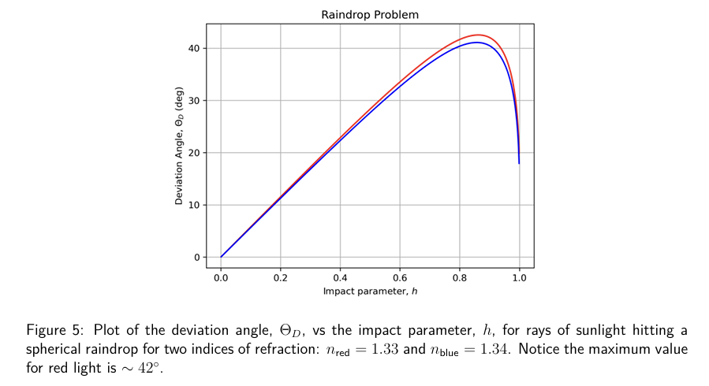

## Problem 5 Solution:

```python
# Part (a):
h, R = 0.6, 1.0
r1 = np.array([-np.sqrt(R**2 - h**2), h])
n_hat = r1 / R   # already unit since R=1

print(f"r1 = {r1}")
print(f"n_hat = {n_hat}")
```

```
r1 = [-0.8  0.6]
n_hat = [-0.8  0.6]
```

```python
# Part (b):
h = 0.6
n_air = 1.0
n_red = 1.3
v_in = np.array([1.0, 0.0])
theta_i = np.arccos(-np.dot(v_in, n_hat))
theta_t = np.arcsin((n_air / n_red) * np.sin(theta_i))

print(f"theta_i = {np.degrees(theta_i):.2f} degrees")
print(f"theta_t = {np.degrees(theta_t):.2f} degrees")
```

```
theta_i = 36.87 degrees
theta_t = 27.49 degrees
```

```python
# Part (c):
def rotation_matrix(theta):
    return np.array([[np.cos(theta), -np.sin(theta)],
                     [np.sin(theta),  np.cos(theta)]])

v_trans = rotation_matrix(theta_t) @ (-n_hat)

print(f"v_trans = {v_trans}")
```

```
v_trans = [ 0.98661924 -0.16304135]
```

```python
# Part (d):
t_hat = v_trans / np.linalg.norm(v_trans)
a_coef = 1.0
b_coef = 2 * np.dot(r1, t_hat)
c_coef = np.dot(r1, r1) - R**2
discriminant = b_coef**2 - 4*c_coef
s1 = (-b_coef - np.sqrt(discriminant)) / 2
s2 = (-b_coef + np.sqrt(discriminant)) / 2
r2 = r1 + s2 * t_hat

print(f"r2 = {r2}")
print(f"s1 = {s1:.2f}, s2 = {s2:.2f}")
```

```
r2 = [0.95049971 0.31072545]
s1 = 0.00, s2 = 1.77
```

```python
#Part (e):
n2_hat = -r2 / np.linalg.norm(r2)
v_refl = t_hat - 2 * np.dot(t_hat, n2_hat) * n2_hat

print(f"n2_hat = {n2_hat}")
print(f"v_refl = {v_refl}")
```

```
n2_hat = [-0.95049971 -0.31072545]
v_refl = [-0.69979575 -0.714343  ]
```

```python
# Part (f):
r_hat = v_refl / np.linalg.norm(v_refl)
b2 = 2 * np.dot(r2, r_hat)
c2 = np.dot(r2, r2) - R**2
s3 = (-b2 + np.sqrt(b2**2 - 4*c2)) / 2
r3 = r2 + s3 * r_hat

n3_hat = r3 / np.linalg.norm(r3)          # outward normal at r3
inward_n3 = -n3_hat
theta_i3 = np.arccos(np.dot(-v_refl, inward_n3))
theta_t3 = np.arcsin((n_red / n_air) * np.sin(theta_i3))
v_exit = rotation_matrix(-theta_t3) @ n3_hat

print(f"r3 = {r3}")
print(f"n3_hat = {n3_hat}")
print(f"theta_i3 = {np.degrees(theta_i3):.2f} degrees")
print(f"theta_t3 = {np.degrees(theta_t3):.2f} degrees")
print(f"v_exit = {v_exit}")
```

```
r3 = [-0.29110617 -0.95669075]
n3_hat = [-0.29110617 -0.95669075]
theta_i3 = 27.49 degrees
theta_t3 = 36.87 degrees
v_exit = [-0.80689939 -0.5906889 ]
```

```python
#part (g):
Theta_D = np.degrees(np.arccos(-np.dot(v_in, v_exit)))

print(f"Deflection angle Theta_D = {Theta_D:.2f} degrees")
```

```
Deflection angle Theta_D = 36.21 degrees
```

```
Red  light rainbow angle: 42.39 deg  at h = 0.8624  (n = 1.33083)
Blue light rainbow angle: 41.57 deg  at h = 0.8594  (n = 1.33650)

Blue light is deviated less than red light.
```

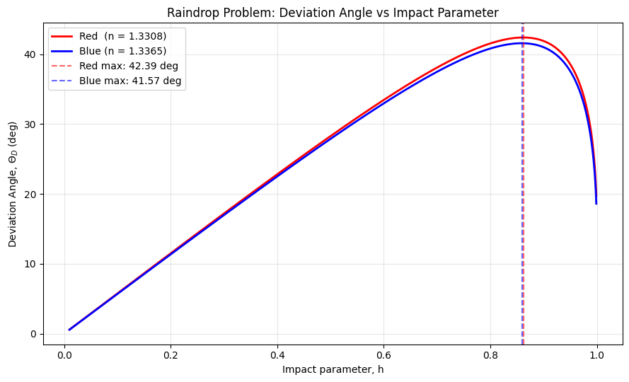

```python
# Part (h): Automate parts (a)-(g) into a function and sweep h over (0, 1)
# Use n values from Problem 3 Cauchy fit (n_red_rep, n_blue_rep)
n_air_rain = 1.0
n_red_rain  = n_red_rep   # ~1.331 at 700 nm
n_blue_rain = n_blue_rep  # ~1.337 at 450 nm

def raindrop_deviation(h, n_water, R=1.0):
    """
    Trace a sunray entering a spherical raindrop at height h.
    Returns the deviation angle Theta_D in degrees (parts a-g in one function).
    """
    # (a) Entry point and outward unit normal
    r1 = np.array([-np.sqrt(R**2 - h**2), h])
    n_hat_1 = r1 / R

    # (b) Incident angle and transmitted angle (Snell's law, air -> water)
    v_in = np.array([1.0, 0.0])
    theta_i = np.arccos(np.clip(-np.dot(v_in, n_hat_1), -1.0, 1.0))
    sin_t = (n_air_rain / n_water) * np.sin(theta_i)
    if abs(sin_t) > 1.0:
        return np.nan
    theta_t = np.arcsin(sin_t)

    # Rotation matrix helper
    def R_mat(angle):
        return np.array([[np.cos(angle), -np.sin(angle)],
                         [np.sin(angle),  np.cos(angle)]])

    # (c) Refracted ray direction inside drop: rotate -n_hat CCW by theta_t
    v_trans = R_mat(theta_t) @ (-n_hat_1)

    # (d) Find r2 — next intersection of ray with drop boundary
    t_hat = v_trans / np.linalg.norm(v_trans)
    b = 2 * np.dot(r1, t_hat)
    c = np.dot(r1, r1) - R**2
    s2 = (-b + np.sqrt(b**2 - 4*c)) / 2   # larger root
    r2 = r1 + s2 * t_hat

    # (e) Internal reflection at r2 using reflection formula from Problem 4
    n2_hat = -r2 / np.linalg.norm(r2)      # interior normal
    v_refl = t_hat - 2 * np.dot(t_hat, n2_hat) * n2_hat

    # (f) Find r3 — exit intersection; compute exit refraction (water -> air)
    r_hat = v_refl / np.linalg.norm(v_refl)
    b3 = 2 * np.dot(r2, r_hat)
    c3 = np.dot(r2, r2) - R**2
    s3 = (-b3 + np.sqrt(b3**2 - 4*c3)) / 2
    r3 = r2 + s3 * r_hat
    n3_hat = r3 / np.linalg.norm(r3)       # outward normal at exit point

    theta_i3 = np.arccos(np.clip(np.dot(-v_refl, -n3_hat), -1.0, 1.0))
    sin_t3 = (n_water / n_air_rain) * np.sin(theta_i3)
    if abs(sin_t3) > 1.0:
        return np.nan                       # total internal reflection — no exit
    theta_t3 = np.arcsin(sin_t3)
    v_exit = R_mat(-theta_t3) @ n3_hat     # rotate n3_hat CW by theta_t3

    # (g) Deviation angle between -v_in and v_exit
    return np.degrees(np.arccos(np.clip(-np.dot(v_in, v_exit), -1.0, 1.0)))

# Sweep h from just above 0 to just below 1
h_vals = np.linspace(0.01, 0.999, 1000)
Theta_red  = np.array([raindrop_deviation(h, n_red_rain)  for h in h_vals])
Theta_blue = np.array([raindrop_deviation(h, n_blue_rain) for h in h_vals])

# Find rainbow angle = maximum deviation
idx_red  = np.nanargmax(Theta_red)
idx_blue = np.nanargmax(Theta_blue)

print(f"Red  light rainbow angle: {Theta_red[idx_red]:.2f} deg  at h = {h_vals[idx_red]:.4f}  (n = {n_red_rain:.5f})")
print(f"Blue light rainbow angle: {Theta_blue[idx_blue]:.2f} deg  at h = {h_vals[idx_blue]:.4f}  (n = {n_blue_rain:.5f})")
print(f"\nBlue light is deviated {'more' if Theta_blue[idx_blue] > Theta_red[idx_red] else 'less'} than red light.")

# Plot Theta_D(h) for both colors
plt.figure(figsize=(9, 5.5))
plt.plot(h_vals, Theta_red,  color='red',  linewidth=2, label=f'Red  (n = {n_red_rain:.4f})')
plt.plot(h_vals, Theta_blue, color='blue', linewidth=2, label=f'Blue (n = {n_blue_rain:.4f})')
plt.axvline(h_vals[idx_red],  color='red',  linestyle='--', alpha=0.6,
            label=f'Red max: {Theta_red[idx_red]:.2f} deg')
plt.axvline(h_vals[idx_blue], color='blue', linestyle='--', alpha=0.6,
            label=f'Blue max: {Theta_blue[idx_blue]:.2f} deg')
plt.xlabel('Impact parameter, h')
plt.ylabel(r'Deviation Angle, $\Theta_D$ (deg)')
plt.title('Raindrop Problem: Deviation Angle vs Impact Parameter')
plt.legend()
plt.grid(True, alpha=0.3)
plt.tight_layout()
plt.show()
```